# Results

Shira Salingre

# Objectives

1. To estimate the amount of non-stationarity in interspecific interactions within fish communities across the Mediterranean Sea.
2. To estimate the amount of non-stationarity in interspecific interactions within fish communities within and outside MPAs.

# Predictions:

1. Temperature effect:
1. More **positive** associations
2. More **negative** associations
- CREATE A GRAPH (X = TEMPERATURE; Y = SUM OF ASSOCIATIONS or COUNT OF POSITIVE/NEGATIVE ASSOCIATIONS)
2. MPA effect:
1. More species/individuals/biomass can be translated to more associations
2. In biomass model - more associations

# Data

## Species

In order to examine the association between species and how this association changes along environmental gradient, I chose three groups of representative fish species (taxa): groupers (Epinephelus species + Serranus species), seabream species and herbivorous species.

## Covariates

I included 6 covariates:

- Annual surface temperature (standardised)
- Mean depth (standardised)
- MPAs - unprotected (enforcement level 0-1) or protected (2-3)
- Primary productivity (standardised)
- Salinity (standardised)
- Country - to account for spatial autocorrelation (coordinates are rough, so I used country instead)

## Model

I’m using the MRF-based model from `MRFcov` package (Clark *et al.* [^1]) to detemine the level and direction of species association in each group.

# Analyses

## Compare association coefficients

Association coefficients describe the relationship between species. Looking at the mean species correlations (**associations**), we can see a stationary (static) or non-stationary (dynamic) pattern:

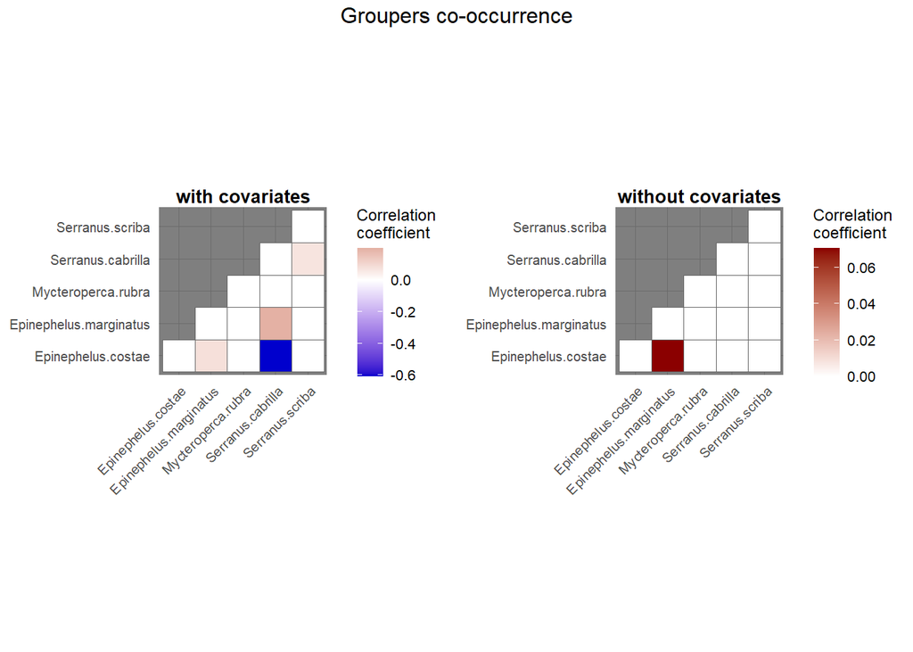

```r
# Groupers
gridExtra::grid.arrange(grpsHM_cov, grpsHM_nocov, nrow = 1, top = "Groupers co-occurrence")
```

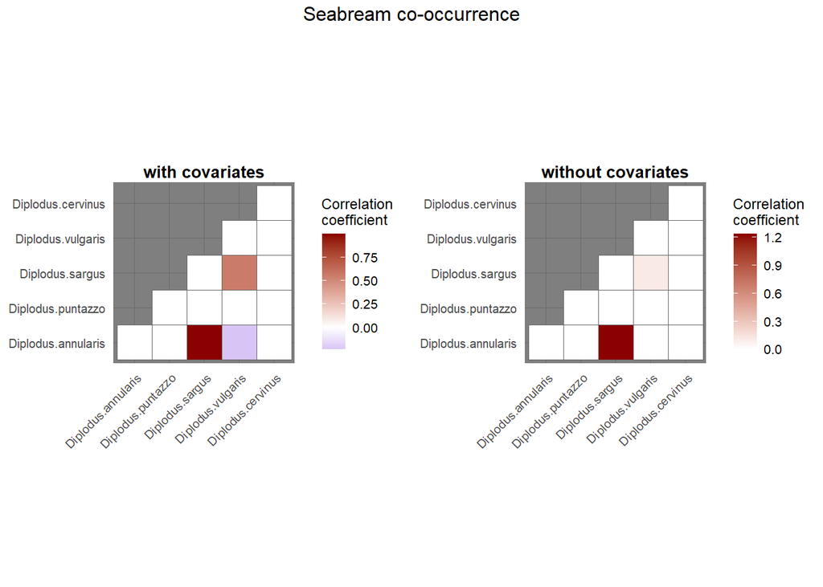

```r
# Seabreams
gridExtra::grid.arrange(dipHM_cov, dipHM_nocov, nrow = 1, top = "Seabream co-occurrence")
```

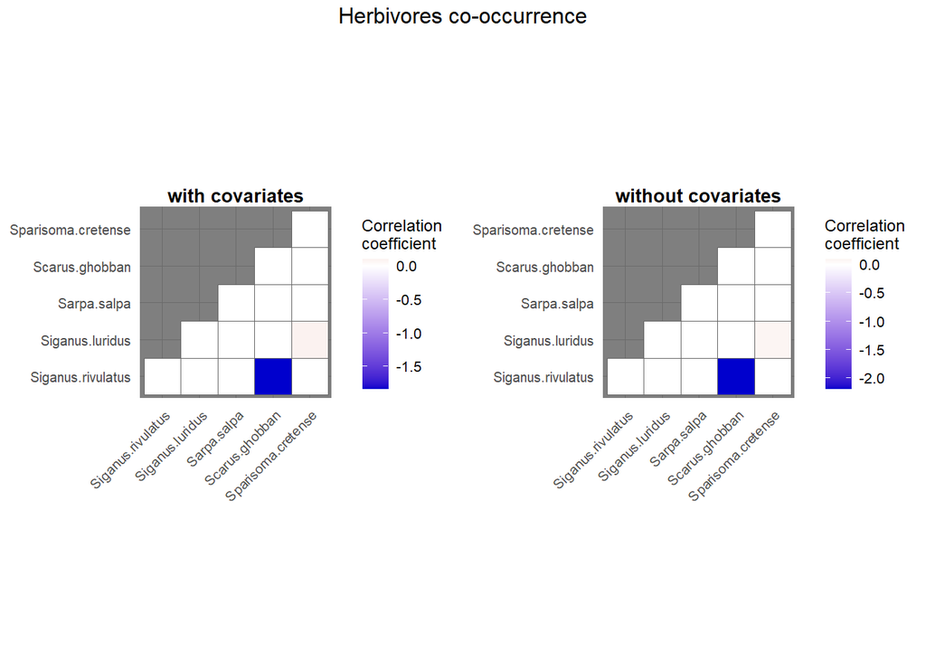

```r
# Herbivores
gridExtra::grid.arrange(herbHM_cov, herbHM_nocov, nrow = 1, top = "Herbivores co-occurrence")
```

## Number of associations

```r
all_assoc
```

```
## $groupers
## # A tibble: 5 x 2
##   species                associations
##   <chr>                         <int>
## 1 Epinephelus.costae                5
## 2 Epinephelus.marginatus            9
## 3 Mycteroperca.rubra                4
## 4 Serranus.cabrilla                11
## 5 Serranus.scriba                   8
##
## $seabream
## # A tibble: 5 x 2
##   species            associations
##   <chr>                     <int>
## 1 Diplodus.annularis            5
## 2 Diplodus.puntazzo             2
## 3 Diplodus.sargus               8
## 4 Diplodus.vulgaris             4
## 5 Diplodus.cervinus             1
##
## $herbivores
## # A tibble: 5 x 2
##   species            associations
##   <chr>                     <int>
## 1 Siganus.rivulatus             4
## 2 Siganus.luridus               3
## 3 Sarpa.salpa                   6
## 4 Scarus.ghobban                3
## 5 Sparisoma.cretense            6
```

## Relative importance of covariates

### Per species

```r
all_relimp
```

```
## $groupers
## # A tibble: 5 x 5
##   species                env_rel_imp anthro_rel_imp biotic_rel_imp inter_rel_imp
##   <chr>                        <dbl>          <dbl>          <dbl>         <dbl>
## 1 Epinephelus.costae           0             0              0.416         0.570
## 2 Epinephelus.marginatus       0             0.0769         0.422         0.500
## 3 Mycteroperca.rubra           0.381         0.618          0             0
## 4 Serranus.cabrilla            0.520         0              0.193         0.254
## 5 Serranus.scriba              0.705         0.224          0.0142        0.0401
##
## $seabream
## # A tibble: 5 x 5
##   species            env_rel_imp anthro_rel_imp biotic_rel_imp inter_rel_imp
##   <chr>                    <dbl>          <dbl>          <dbl>         <dbl>
## 1 Diplodus.annularis      0.0211         0              0.167         0.778
## 2 Diplodus.puntazzo       0.661          0.339          0             0
## 3 Diplodus.sargus         0.785          0.109          0.0175        0.0746
## 4 Diplodus.vulgaris       0.921          0.0592         0             0
## 5 Diplodus.cervinus       0.999          0              0             0
##
## $herbivores
## # A tibble: 5 x 5
##   species            env_rel_imp anthro_rel_imp biotic_rel_imp inter_rel_imp
##   <chr>                    <dbl>          <dbl>          <dbl>         <dbl>
## 1 Siganus.rivulatus        0.980         0.0145          0             0
## 2 Siganus.luridus          0             0               0.417         0.583
## 3 Sarpa.salpa              0.906         0.0941          0             0
## 4 Scarus.ghobban           0             0               0.424         0.576
## 5 Sparisoma.cretense       0.798         0.196           0             0
```

**Groupers**

**Seabreams**

- *Diplodus vulgaris* is mostly affected by environmental variables.
- *Diplodus cervinus* is affected only by environmental variables.

**Herbivores**  
*Siganus rivulatus* and *Sarpa salpa* are highly effected by environmental variables. They may have a simialr response to environmental variations.

### Per taxa

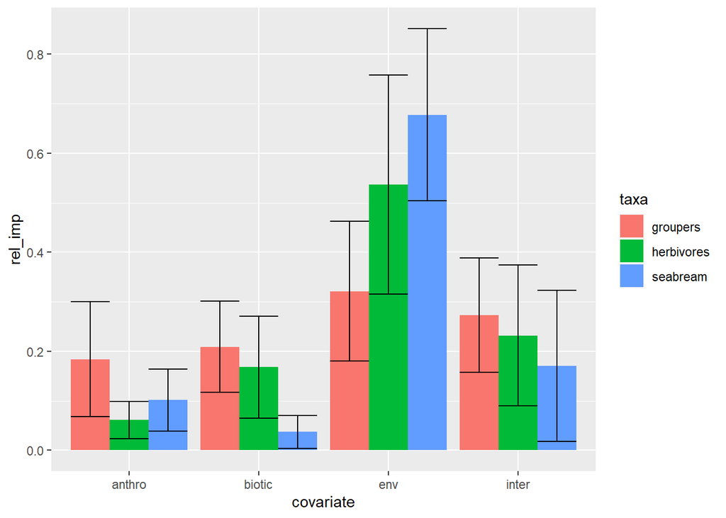

```r
all_relimp %>% bind_rows(.id = "taxa") %>%
  pivot_longer(3:6) %>% # Create a tibble of all taxa
  rename(taxa = taxa, species = species, covariate = name, rel_imp = value) %>%
  mutate(covariate = str_remove(string = covariate, pattern = "_rel_imp")) %>%
  ggplot() +
  aes(x = covariate, y = rel_imp, fill = taxa)+
  stat_summary(geom = "bar", fun = mean, position = "dodge")+
  stat_summary(geom = "errorbar", fun.data = mean_se, position = "dodge")
```

There’s a large variance between species in the taxa so maybe this isn’t the right way to look at it.

[^1]: Clark, Nicholas J., Konstans Wells, and Oscar Lindberg. “Unravelling changing interspecific interactions across environmental gradients using Markov random fields.” Ecology 99.6 (2018): 1277-1283.